# A model-based biomass index of greater weever

Aqua skill-sharing sessions

Max Lindmark

2025-10-13

## Greater weever

- Widely distributed in the North-East Atlantic
  - In Sweden: Skagerrak, Kattegatt och Öresund
- No quota
- Mostly caught as bycatch in industrial pelagic fisheries
- Landings fluctuate across years; high when targeted
- High age & catchability, and slow growth make it susceptible to overfishing.

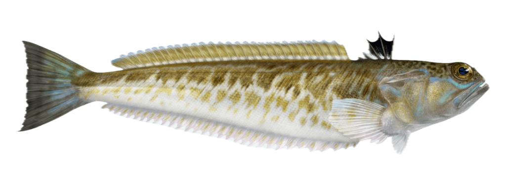

Illustration: Karl Jilg, SLU Artdatabanken

## Fiskbarometern

- The status of greater weever in Fiskbarometern is largely based on an index of biomass
- Two types of indices: design or model based

## Indices from fishery-independent surveys

**Design-based**

- Rely on the randomness of the sampling locations
- Estimates the (fixed) index value as the area-weighted stratified mean for each stratum
- Limited ability to account for environmental covariates or spatial structure

**Model-based**

- An underlying stochastic process generating the data, described by a statistical model
- Incorporate covariates and spatial correlations
- Predictions at unsampled locations

Cao et al (2015) CJFAS

## Spatiotemporal model for index standardisation

- Spatial autocorrelation: correlation depends on distance: No concern!
- *Residual* spatial autocorrelation: Big concern! Violates statistical assumptions
- Inference doesn’t have to be affected by RSA, but they can be so we need to address this

## Spatiotemporal model for index standardisation

- sdmTMB: TMB and R for fitting and fmesher for setting up SPDE (stochastic partial differential equation) matrices
- Allows us to model spatially correlated latent processes as GMRFs
- See previous session on sdmTMB for more background!

Anderson et al., (2025) *bioRxiv*

## Spatiotemporal GLMs

$$\begin{aligned}
\mathbb{E}[y_{\boldsymbol{s},t}] &= \mu_{\boldsymbol{s},t},\\
\mu_{\boldsymbol{s},t} &=
f^{-1} \left( \boldsymbol{X}^{\mathrm{main}}_{\boldsymbol{s},t} \boldsymbol{\beta} +
\boldsymbol{X}^{\mathrm{svc}}_{\boldsymbol{s},t} \zeta_{\boldsymbol{s}} + \boldsymbol{X}^{\mathrm{tvc}}_{\boldsymbol{s},t} \gamma_{\boldsymbol{t}}
+ \epsilon_{\boldsymbol{s},t} \right)
\end{aligned}$$

- $y_{\boldsymbol{s},t}$: density [$\text{kg/km}^2$] at point $\boldsymbol{s}$ and time $t$
- $\mu$: mean
- $f$: link function
- $\boldsymbol{X}^{\mathrm{main}}$, $\boldsymbol{X}^{\mathrm{svc}}$, and $\boldsymbol{X}^{\mathrm{tvc}}$: design matrices (‘main’ = main effects, ‘svc’ = spatially-varying coefficients, and ‘tvc’ = time-varying coefficients)
- $\boldsymbol{\beta}$: vector of fixed-effect coefficients
- $\zeta_{\boldsymbol{s}}$: spatially varying coefficients (a random field for each quarter), $\zeta_{\boldsymbol{s}} \sim \mathrm{MVN}(\boldsymbol{0},\boldsymbol{\Sigma}_\zeta)$
- $\gamma_{\boldsymbol{t}}$: time-varying intercept (ar1), $\gamma_{\boldsymbol{t=1}} \sim \operatorname{N}(0, \sigma_\gamma^2)$, $\gamma_{\boldsymbol{t>1}} \sim \operatorname{N}(\rho_\gamma \gamma_{t-1}, \sqrt{1-\rho_\gamma^2 \sigma_\gamma^2})$
- $\epsilon_{\boldsymbol{s},t}$: spatiotemporal random field, $\epsilon_{\boldsymbol{s},t} \sim \mathrm{MVN}(\boldsymbol{0},\boldsymbol{\Sigma}_{\epsilon})$
- delta-gamma observation model

## It’s generally a good idea to start simple…

## data

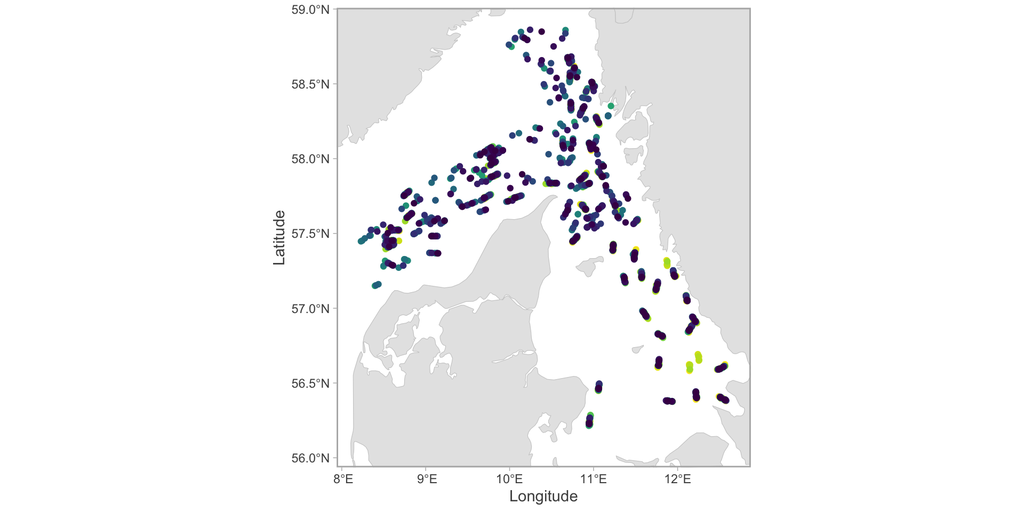

## m0

```r
m0 <- sdmTMB(
  formula = density ~ s(depth_sc) + temp_sc + quarter_f,
  data = d,
  mesh = mesh,
  family = delta_gamma(type = "poisson-link"),
  time_varying = ~1,
  time_varying_type = "ar1",
  spatiotemporal = "off",
  spatial = "off",
  time = "year")
```

## m1

```r
m1 <- sdmTMB(
  formula = density ~ s(depth_sc) + temp_sc + quarter_f,
  data = d,
  mesh = mesh,
  family = delta_gamma(type = "poisson-link"),
  time_varying = ~1,
  time_varying_type = "ar1",
  spatiotemporal = list("off", "iid"),
  spatial = "on",
  time = "year")
```

## m1

```r
nd_depth <- tibble(depth = modelr::seq_range(d$depth, n = 50)) |>
  mutate(temp_sc = 0,
         depth_sc = as.numeric(scale(depth)),
         depth_sq = depth_sc*depth_sc,
         quarter_f = as.factor(3),
         year = 1999,
         year_f = as.factor(1999))

p_depth <- predict(m1, newdata = nd_depth,
                   re_form = NA, re_form_iid = NA)
```

## m1

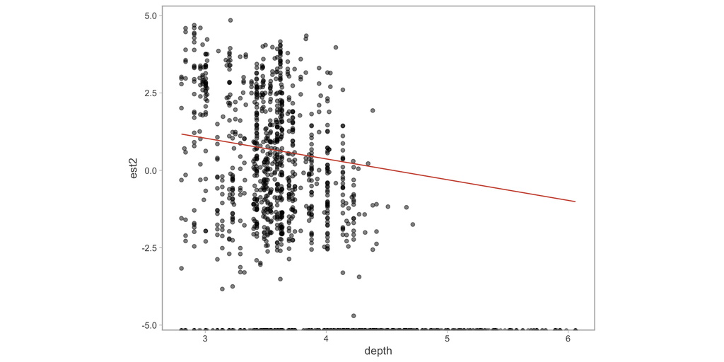

## m2

```r
m2 <- sdmTMB(
  formula = list(density ~ depth_sc + depth_sq + temp_sc + quarter_f,
                 density ~ depth_sc + temp_sc + quarter_f),
  data = d,
  mesh = mesh,
  family = delta_gamma(type = "poisson-link"),
  time_varying = ~1,
  time_varying_type = "ar1",
  spatiotemporal = list("off", "iid"),
  spatial = "on",
  time = "year")
```

## m2

```r
pred <- predict(m2, newdata = pred_grid |> filter(quarter == 3))

plot_map_fc +
  geom_raster(data = pred,
              aes(X*1000, Y*1000, fill = exp(epsilon_st2))) +
  scale_fill_viridis(name = "Density (kg/km2)", trans = "sqrt") +
  facet_wrap(~year, ncol = 7) +
  theme_sleek(base_size = 9) +
  theme(
    legend.position.inside = c(0.195, 0.75),
    legend.direction = "vertical",
    legend.key.width = unit(0.2, "cm"),
    legend.key.height = unit(0.3, "cm"),
    legend.title = element_text(size = 6)) +
  guides(
    fill = guide_colorbar(
    position = "bottom",
    title.position = "top",
    direction = "horizontal",
    title.hjust = 1,
    theme = theme(legend.key.width  = unit(3, "cm")))) +
  geom_sf() +
  labs(subtitle = "Quarter 3")
```

## m2

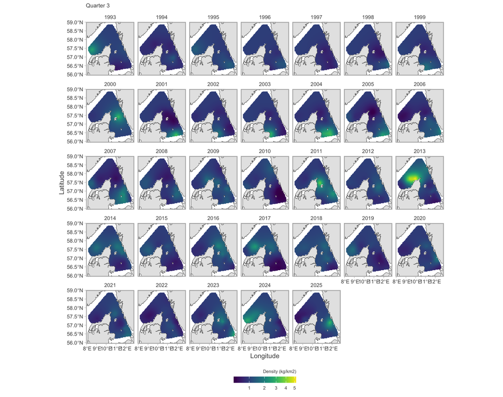

## m3

```r
m3 <- sdmTMB(
  formula = list(density ~ depth_sc + depth_sq + temp_sc + quarter_f,
                 density ~ depth_sc + temp_sc + quarter_f),
  data = d,
  mesh = mesh,
  family = delta_gamma(type = "poisson-link"),
  time_varying = ~1,
  time_varying_type = "ar1",
  spatiotemporal = list("off", "ar1"),
  spatial = "on",
  time = "year")
```

## m3

```
Spatiotemporal model fit by ML ['sdmTMB']
Formula: list(density ~ depth_sc + depth_sq + temp_sc + quarter_f, density ~
 Formula:     depth_sc + temp_sc + quarter_f)
Mesh: mesh (isotropic covariance)
Time column: year
Data: d
Family: delta_gamma(link1 = 'log', link2 = 'log', type = 'poisson-link')

Delta/hurdle model 1: -----------------------------------
Family: binomial(link = 'log')
Conditional model:
            coef.est coef.se
(Intercept)    -2.03    0.79
depth_sc       -1.85    0.29
depth_sq       -0.76    0.20
temp_sc         0.95    0.30
quarter_f3     -0.12    0.63

Time-varying parameters:
                   coef.est    coef.se
(Intercept)-1993 -0.7800000 0.62000000
(Intercept)-1994 -0.7900000 0.62000000
(Intercept)-1995 -1.0800000 0.63000000
(Intercept)-1996 -1.3600000 0.64000000
(Intercept)-1997 -1.2600000 0.64000000
(Intercept)-1998 -0.9500000 0.63000000
(Intercept)-1999 -0.8700000 0.63000000
(Intercept)-2000 -0.5300000 0.64000000
(Intercept)-2001 -0.3300000 0.62000000
(Intercept)-2002 -0.3900000 0.62000000
(Intercept)-2003 -0.1400000 0.62000000
(Intercept)-2004  0.1300000 0.62000000
(Intercept)-2005  0.2700000 0.62000000
(Intercept)-2006  0.4400000 0.62000000
(Intercept)-2007  0.8600000 0.61000000
(Intercept)-2008  1.0600000 0.62000000
(Intercept)-2009  1.1800000 0.62000000
(Intercept)-2010  0.8000000 0.62000000
(Intercept)-2011  0.7500000 0.62000000
(Intercept)-2012  0.5200000 0.62000000
```

[output cut: 58 more lines]

```
(Intercept)-2022  0.2900000 0.52000000
(Intercept)-2023  0.4100000 0.53000000
(Intercept)-2024  0.4300000 0.53000000
(Intercept)-2025  0.4000000 0.52000000
rho-(Intercept)   0.9615202 0.05543323

Dispersion parameter: 1.19
Spatiotemporal AR1 correlation (rho): 0.80
Matérn range: 84.03
Spatial SD: 0.86
Spatiotemporal marginal AR1 SD: 0.76

ML criterion at convergence: 2815.189

See ?tidy.sdmTMB to extract these values as a data frame.
```

## m4

```r
m4 <- sdmTMB(
  formula = list(density ~ depth_sc + depth_sq + temp_sc + quarter_f,
                 density ~ depth_sc + temp_sc + quarter_f),
  data = d,
  mesh = mesh,
  family = delta_gamma(type = "poisson-link"),
  time_varying = ~1,
  time_varying_type = "ar1",
  spatiotemporal = list("off", "ar1"),
  spatial = "off",
  spatial_varying = ~ 0 + quarter_f,
  time = "year")
```

## AIC

AIC favors the spatiotemporal model, with different fields and formula for each component

```
   df      AIC
m0 15 6353.447
m1 20 5702.803
m2 19 5693.374
m3 20 5670.378
m4 22 5331.369
```

## Model fit

Check model fir

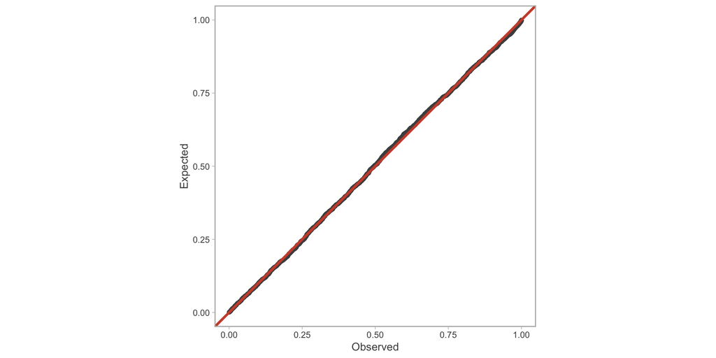

## Estimate a biomass index

```r
pred_tmb_q3 <- predict(
  m4,
  newdata = pred_grid |> filter(quarter == 3),
  return_tmb_object = TRUE)

index_q3 <- get_index(pred_tmb_q3, area = 9, bias_correct = TRUE, level = 0.95)
```

## Estimate a biomass index

```r
ggplot(index_q3, aes(year, est/1000)) +
  geom_ribbon(aes(ymin = lwr/1000, ymax = upr/1000), alpha = 0.3, color = NA) +
  geom_line() +
  scale_color_brewer(palette = "Set1") +
  scale_fill_brewer(palette = "Set1") +
    labs(subtitle = "Spatiotemporal index", color = "Quarter",
         fill = "Quarter", x = "Year", y = "Biomass estimate (tonnes)")
```

## Estimate a biomass index

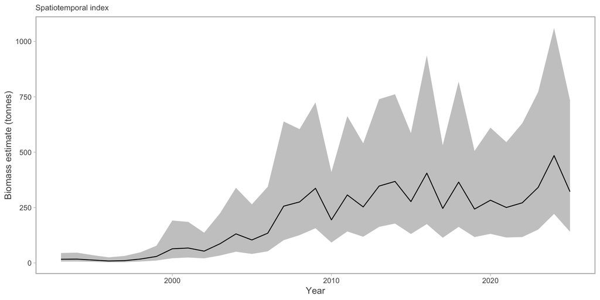

[figure not shown]